# DDS Case Study 1

Ganesh Kodi and Jeff Leath

October 16, 2018

## ** Background **

Backgound:

GJ Brewhouse, is a startup microbrewery that is researching the existing ‘craft brew’ market in the US. They have raised funds that will allow them to grow and they want to survey the landscape to identify space to fill a niche.

GJ Brewhouse has commissioned market research from leading Data Scientist, Ganesh and Jeff, who tutored under world renown Data Scientist, Jacquelyn Cheun.

The principal ‘customer’ at GJ Brewhouse, is JC, who is Vice-President of Analytics. The presentation will have some technical components, at the request of JC.

## Introduction

Good Evening,

We, Jeff and Ganesh, are pleased to report back to you on your request for information and data available relative to the Craft Brew market in the continental US.

We understand your technical prowress, so we will also provide a flavor of the underlying data, code and process.

## Questions

1. How many breweries are present in each state?

The following table displays the total count of breweries in each state.

```r
## Answer Question 1:  Brewery count by state
table(brewery$State)
```

```
##
##  AK  AL  AR  AZ  CA  CO  CT  DC  DE  FL  GA  HI  IA  ID  IL  IN  KS  KY
##   7   3   2  11  39  47   8   1   2  15   7   4   5   5  18  22   3   4
##  LA  MA  MD  ME  MI  MN  MO  MS  MT  NC  ND  NE  NH  NJ  NM  NV  NY  OH
##   5  23   7   9  32  12   9   2   9  19   1   5   3   3   4   2  16  15
##  OK  OR  PA  RI  SC  SD  TN  TX  UT  VA  VT  WA  WI  WV  WY
##   6  29  25   5   4   1   3  28   4  16  10  23  20   1   4
```

2. We have merged the current beer product and active brewery lists to provide a meshed data product. We are displaying a snapshot of the data as an example.
1. These are the first six (6) records.

```r
## Merge files
newtable <- merge(beers, brewery, by="Brewery_id")
## NOT USED str(newtable)

## first 6 records of merged files
head(newtable,6)
```

```
##   Brewery_id          Name Beer_ID   ABV IBU
## 1          1  Get Together    2692 0.045  50
## 2          1 Maggie's Leap    2691 0.049  26
## 3          1    Wall's End    2690 0.048  19
## 4          1       Pumpion    2689 0.060  38
## 5          1    Stronghold    2688 0.060  25
## 6          1   Parapet ESB    2687 0.056  47
##                                 Style Ounces       Brewery_Name
## 1                        American IPA     16 NorthGate Brewing
## 2                  Milk / Sweet Stout     16 NorthGate Brewing
## 3                   English Brown Ale     16 NorthGate Brewing
## 4                         Pumpkin Ale     16 NorthGate Brewing
## 5                     American Porter     16 NorthGate Brewing
## 6 Extra Special / Strong Bitter (ESB)     16 NorthGate Brewing
##          City State
## 1 Minneapolis    MN
## 2 Minneapolis    MN
## 3 Minneapolis    MN
## 4 Minneapolis    MN
## 5 Minneapolis    MN
## 6 Minneapolis    MN
```

2. These are the last six (6) records.

```r
## last 6 records
tail(newtable, 6)
```

```
##      Brewery_id                      Name Beer_ID   ABV IBU
## 2405        556             Pilsner Ukiah      98 0.055  NA
## 2406        557  Heinnieweisse Weissebier      52 0.049  NA
## 2407        557           Snapperhead IPA      51 0.068  NA
## 2408        557         Moo Thunder Stout      50 0.049  NA
## 2409        557         Porkslap Pale Ale      49 0.043  NA
## 2410        558 Urban Wilderness Pale Ale      30 0.049  NA
##                        Style Ounces                  Brewery_Name
## 2405         German Pilsener     12         Ukiah Brewing Company
## 2406              Hefeweizen     12       Butternuts Beer and Ale
## 2407            American IPA     12       Butternuts Beer and Ale
## 2408      Milk / Sweet Stout     12       Butternuts Beer and Ale
## 2409 American Pale Ale (APA)     12       Butternuts Beer and Ale
## 2410        English Pale Ale     12 Sleeping Lady Brewing Company
##               City State
## 2405         Ukiah    CA
## 2406 Garrattsville    NY
## 2407 Garrattsville    NY
## 2408 Garrattsville    NY
## 2409 Garrattsville    NY
## 2410     Anchorage    AK
```

3. You had asked us to quantify the quality of the data. Below, we are displying the number of missing data elements (i.e. NA’s) in for each data field.

```r
## this code counts the N/A for each column
na_count <-sapply(newtable, function(y) sum(length(which(is.na(y)))))
na_count
```

```
##   Brewery_id         Name      Beer_ID          ABV          IBU
##            0            0            0           62         1005
##        Style       Ounces Brewery_Name         City        State
##            0            0            0            0            0
```

4. Compute the median alcohol content and international bitterness unit for each state.

-The table below displays the Median ABV and Meidan IBU for each state.

```r
## calc median ABV by state
medianABV <-aggregate(ABV ~ State, newtable, median)

## calc median IBU by state
medianIBU <-aggregate(IBU ~ State, newtable, median)

## merging the two tables
q4 <- merge(medianABV, medianIBU, by="State")
names(q4) <-c("State","Median ABV","Median IBU")

##Prints the combined table displaying the Median ABV and IBU by state
q4
```

```
##    State Median ABV Median IBU
## 1     AK     0.0560       46.0
## 2     AL     0.0600       43.0
## 3     AR     0.0520       39.0
## 4     AZ     0.0550       20.5
## 5     CA     0.0580       42.0
## 6     CO     0.0605       40.0
## 7     CT     0.0600       29.0
## 8     DC     0.0625       47.5
## 9     DE     0.0550       52.0
## 10    FL     0.0570       55.0
## 11    GA     0.0550       55.0
## 12    HI     0.0540       22.5
## 13    IA     0.0555       26.0
## 14    ID     0.0565       39.0
```

[output cut: 36 more lines]

These bar plots provide two vantage points of the Median ABV and Meidan IBU.

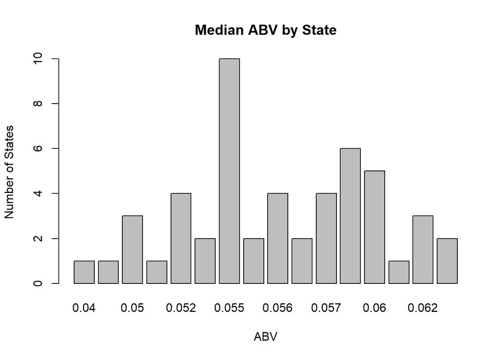

```r
## bar plot for median ABV
countABV <- table(medianABV$ABV)
barplot(countABV, main="Median ABV by State",
        xlab="ABV", ylab = "Number of States")
```

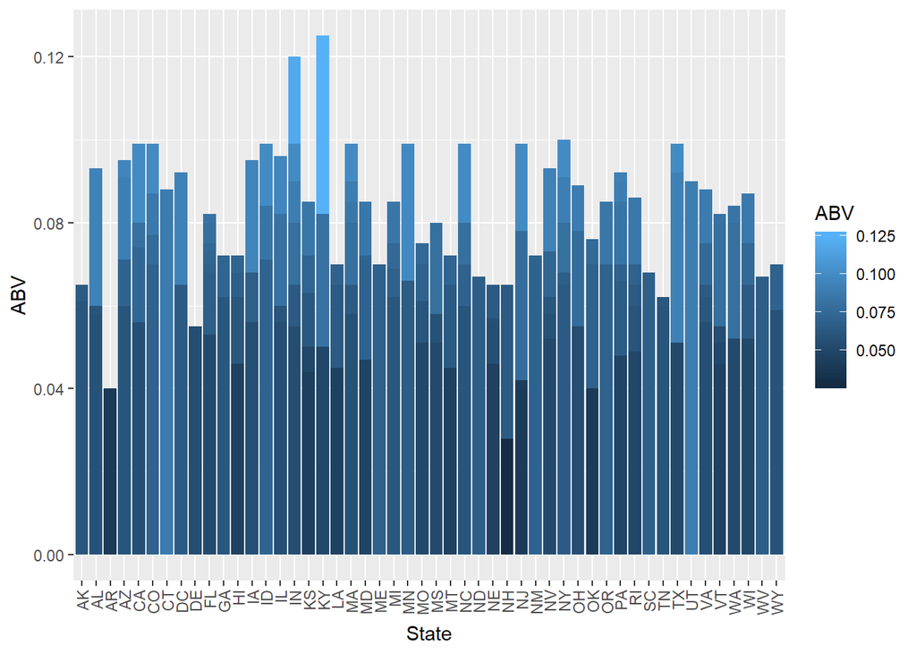

```r
## comparing alcoholic content along different states
ggplot(na.omit(newtable),aes(x=State, y=ABV))+geom_bar(aes(fill = ABV),stat = "identity",position = "dodge")+theme(axis.text.x=element_text(angle=90,hjust=1,vjust=0.5))
```

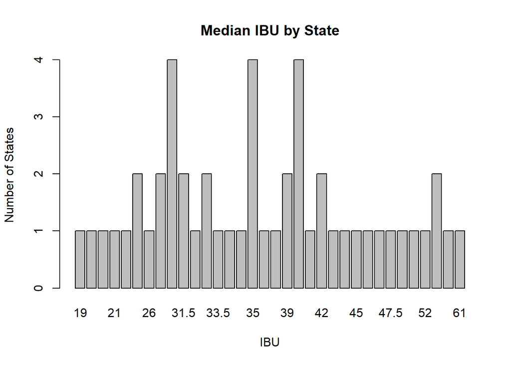

```r
## bar plot for median IBU
countIBU <- table(medianIBU$IBU)
barplot(countIBU, main="Median IBU by State",
        xlab="IBU", ylab = "Number of States")
```

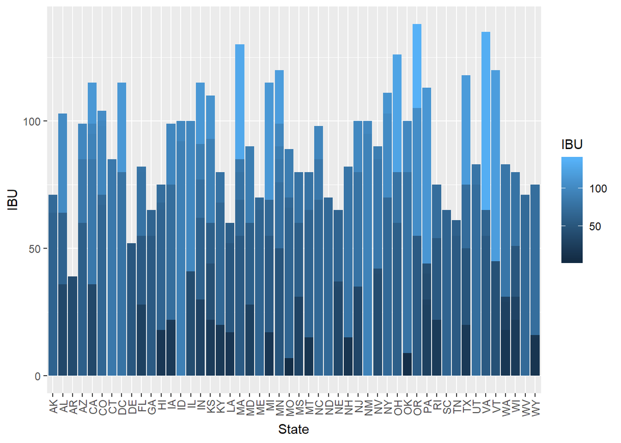

```r
## comparing bitterness values along different states
ggplot(na.omit(newtable),aes(x=State, y=IBU))+geom_bar(aes(fill = IBU),stat = "identity",position = "dodge")+theme(axis.text.x=element_text(angle=90,hjust=1,vjust=0.5))
```

5. Which state has the maximum alcoholic (ABV) beer? Which state has the most bitter (IBU) beer?
1. State with maximun alcoholic beer :

```r
## State which is having maximum alcoholic content
## Find Max alcoholic content beer (column ABV) from newtable
## Identify the index of the max
## Display the value of state column represents the max alcoholic content beer
maxABV <- max(newtable$ABV, na.rm = TRUE)
maxABVIndex <- which(newtable$ABV == maxABV )
trimws(as.character(newtable$State[maxABVIndex]))
```

```
## [1] "CO"
```

```r
## Highest alcoholic content state
## trimws(as.character(medianABV$State[which(medianABV$ABV == max(medianABV$ABV))]))
##
```

2. State with most bitter beer :

```r
## State which is having most bitter content
## Find most bitter content beer (column IBU) from newtable
## Identify the index of the max
## Display the value of state column represents the most bitter content beer
maxIBU <- max(newtable$IBU, na.rm = TRUE)
maxIBUIndex <- which(newtable$IBU == maxIBU )
as.character(newtable$State[maxIBUIndex])
```

```
## [1] " OR"
```

```r
## Most aggregated bitter content state
## trimws(as.character(medianIBU$State[which(medianIBU$IBU == max(medianIBU$IBU))]))
```

6. Summary statistics for the ABV variable.

```r
## Summary of the ABV
summary(newtable$ABV)
```

```
##    Min. 1st Qu.  Median    Mean 3rd Qu.    Max.    NA's
## 0.00100 0.05000 0.05600 0.05977 0.06700 0.12800      62
```

7. Is there an apparent relationship between the bitterness of the beer and its alcoholic content? Draw a scatter plot.

Follwoing Scatter plot shows relation between bitterness and alcoholic content

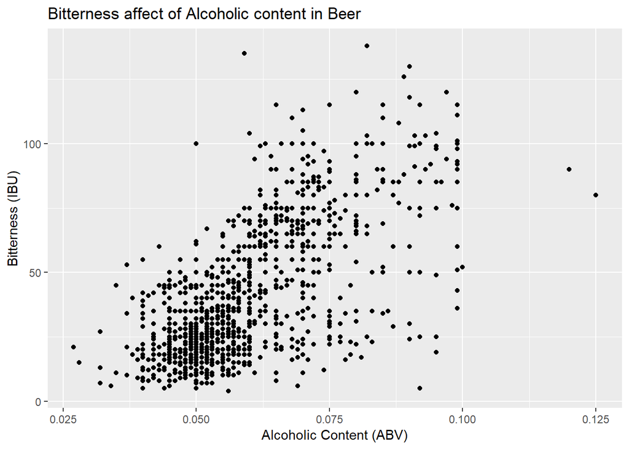

```r
## Draw scatter plot using ggplot2 to determine the relation between ABV and IBU
ggplot(na.omit(newtable), aes(x=ABV, y=IBU))+geom_point()+ylab("Bitterness (IBU)")+xlab("Alcoholic Content (ABV)")+ggtitle("Bitterness affect of Alcoholic content in Beer")
```

Above plot indicates that bitterness value increases with alocoholic content in beer, though there are few exceptions

## Conclussion

In conclussion, after exhaustive study of the available data, we have two recommendations for BJ Brewhouse.

Recommendation 1: With Colorado is having largest number of breweries, availability of resources and expertise make it the best location for starting new factory.

Recommendation 2: New beer recommendation is to start with country wide average: IBU (42.71) and ABV (0.05977)

It was our pleasure to provide this service to BJ Brewhouse. If there are follow-up questions of interest, please let us know.

-Ganesh Kodi

-Jeff Leath